# python的数据结构

## 列表（list）

- range()最常用的列表生成函数
- 什么是列表
- 列表的表示方法——字符串的表示方法

```python
a=[2,5]
b=[2,"d",8.0]
print(a,b)
```

```
[2, 5] [2, 'd', 8.0]
```

- 列表的索引
- 列表的切片： 单个选择， 连续选择， 跳跃选择——类比range()函数
- 分片赋值

```python
b=[3,5,1,2,7]
#  0 1 2 3 4
print(b)
```

```
[3, 5, 1, 2, 7]
```

```python
b[-3]
```

```
1
```

```python
range(1,5)
```

```
range(1, 5)
```

```python
b[1:3]
```

```
[5, 1]
```

```python
b[1:]
```

```
[5, 1, 2, 7]
```

```python
b[2]=5
b
```

```
[3, 5, 5, 2, 7]
```

```python
b[-3:]
```

```
[1, 2, 7]
```

```python
print(b[3],b[2],b[0:3])
```

```
2 1 [3, 5, 1]
```

```python
a1=[3,2,1,5,1,5,8,0,7]
print(a1)
```

```
[3, 2, 1, 5, 1, 5, 8, 0, 7]
```

```python
print(a1[5],a1[2:5],a1[6:])
```

```
5 [1, 5, 1] [8, 0, 7]
```

```python
print(a1[0:5:2],a1[-3:],a1[-2:-4])
```

```
[3, 1, 1] [8, 0, 7] []
```

```python
print(a1)
```

```
[3, 2, 1, 5, 1, 5, 8, 0, 7]
```

```python
a1[1]=99
print(a1)
```

```
[3, 99, 1, 5, 1, 5, 8, 0, 7]
```

- 列表加法与乘法

```python
a=[1,4]
b=[3,5]
print(a+b)
print(a*3)
```

```
[1, 4, 3, 5]
[1, 4, 1, 4, 1, 4]
```

- 用于list的内建函数： len,max,min,sum

```python
a=[1,4,9,2,7,3,0]
print(len(a),max(a),min(a),sum(a))
```

```
7 9 0 26
```

```python
a="wappp"
print(len(a),max(a))
a.append("r")
```

```
5 w
```

```
---------------------------------------------------------------------------
AttributeError                            Traceback (most recent call last)
<ipython-input-11-39660bcdbccb> in <module>()
      1 a="wappp"
      2 print(len(a),max(a))
----> 3 a.append("r")

AttributeError: 'str' object has no attribute 'append'
```

- 复杂数据类型的方法（ method） ， 特定的方法只能作用到特定的类型上
- 列表最简单的最有用的方法： append()
- 定义空列表， 并用append() 生成一个你想要的列表

```python
a=[2,5,1,6]
```

```python
a.append(4)
```

```python
a.insert(2,1)
```

```python
a.pop(2)#按位置删除
```

```
1
```

```python
a.remove(6)
```

```python
a
```

```
[2, 5, 1, 4, 4]
```

```python
a=[2,5,1,6]
a.append(7)
print(a)
print(a.append(8))
print(a)
```

```
[2, 5, 1, 6, 7]
None
[2, 5, 1, 6, 7, 8]
```

```python
for i in [2,"a",4,5]:
    print(i)
```

```
2
a
4
5
```

```python
for i in range(1,5):
    print(i)
```

```
1
2
3
4
```

```python
a=[2,3,4,5]
for i in a:
    print(i)
```

```
2
3
4
5
```

```python
a=[]
for i in range(1,6):
    if i%2==0:
        a.append(i)
print(a)
```

```
[2, 4]
```

```python
for i in range(2,5):
    print(i)
```

```
2
3
4
```

```python
def jjj(b):
    a=[]
    for i in b:
        if i<3:
            a.append(i)
    return a

print(jjj([2,4,5,2,21,3,1,1,2]))
```

```
[2, 2, 1, 1, 2]
```

```python
a=[2,4,5]
print(1 in a,2 in a)
```

```
False True
```

```python
a
```

```
[2, 5, 1, 4, 4]
```

```python
help(a.sort)
```

```
Help on built-in function sort:

sort(*, key=None, reverse=False) method of builtins.list instance
    Stable sort *IN PLACE*.
```

```python
a1=[3,4,1]
a1.sort(reverse=True)
```

```python
a1
```

```
[4, 3, 1]
```

```python
a.reverse()
```

```python
a
```

```
[5, 4, 4, 2, 1]
```

- 其他方法： sort,reverse,count,extend,index,insert,pop,remove
- 方法与内建函数的区别

```python
a=[2,5,1,6]
print(a.sort())
print(a)
```

```
None
[1, 2, 5, 6]
```

```python
a=[2,1,4,32,5,31,2]
a.sort()
print(a[0:2])
```

```
[1, 2]
```

```python
a=[2,5,1,6]
a.reverse()
print(a)
```

```
[6, 1, 5, 2]
```

```python
a=[1,4,2,1,6,3,2,2]
print(a.count(2))
```

```
3
```

```python
a=[2,4]
b=[1,22]
a.extend(b)
print(a)
```

```
[2, 4, 1, 22]
```

```python
a=[2, 4, 8, 5]
print(a.index(8))
a.insert(1,5)
print(a)
```

```
2
[2, 5, 4, 8, 5]
```

```python
print(a.pop(4))
print(a)
```

```
5
[2, 5, 4, 8]
```

```python
print(a)
a.remove(4)
print(a)
```

```
[2, 5, 4, 8]
[2, 5, 8]
```

- 基于列表的迭代
- enumerate

```python
for i in [1,2,3]:
    print(i)
```

```
1
2
3
```

```python
a=[1,4,2,0,2,6]
for i,j in enumerate(a):
    print(i,j)
```

```
0 1
1 4
2 2
3 0
4 2
5 6
```

## 已知:

- 用于list的内建函数： len,max,min,sum

```python
a=[5,2,8,1,5]
print len(a),max(a),min(a),sum(a),a
```

```
5 8 1 21 [5, 2, 8, 1, 5]
```

- 请阅读如下程序自学list的“方法”的用法和效果： sort,reverse,count,extend,index,insert,pop,remove
- 特别注意“方法”与内建函数的区别

```python
a=[2,4,1,4,2]
a.sort()
print a
a.reverse()
print a
print a.count(4)
a.extend([3,2])
print a
print a.index(1)
a.insert(1,9)
print a
a.pop(3)
print a
a.pop()
print a
a.remove(4)
print a
a.remove(1)
print a
```

```
[1, 2, 2, 4, 4]
[4, 4, 2, 2, 1]
2
[4, 4, 2, 2, 1, 3, 2]
4
[4, 9, 4, 2, 2, 1, 3, 2]
[4, 9, 4, 2, 1, 3, 2]
[4, 9, 4, 2, 1, 3]
[9, 4, 2, 1, 3]
[9, 4, 2, 3]
```

- append()方法与循环,通过append构建列表

```python
a=[]
for i in range(1,100):
    if i%3==0:
        a.append(i)
print(a)
```

```
[3, 6, 9, 12, 15, 18, 21, 24, 27, 30, 33, 36, 39, 42, 45, 48, 51, 54, 57, 60, 63, 66, 69, 72, 75, 78, 81, 84, 87, 90, 93, 96, 99]
```

```python
a=[]
for i in range(1,5):
    a.append(i*2)
print a
```

```
[2, 4, 6, 8]
```

```python
a=[]
for i in range(2,12):
    a.append(i/3.2)
print a
```

```
[0.625, 0.9375, 1.25, 1.5625, 1.875, 2.1875, 2.5, 2.8125, 3.125, 3.4375]
```

```python
a=[2,5,6,2]
b=[]
for i in a:

    b.append(i)
print b
```

```
[2, 5, 6, 2]
```

```python
a=[2,4]
print 1 in a, 2 in a,1 not in a
```

```
False True True
```

## 请编程打印如下结果

```python
#已知列表a=[2,1,4,6,11,9,2,7,9,12,4,3,10,21]，利用a以及上面所学的“方法”求如下结果,注意后面题目可能改动列表a，那么之后的题目就在改动后的a上完成

a=[2,1,4,6,11,9,2,7,9,12,4,3,10,21]
```

```python
#利用a进行切片操作求如下结果
```

```
4 [2, 1, 4, 6, 11, 9] [6, 9, 7, 12]
```

```python
#######后面添加元素8并输出结果#########
```

```
[2, 1, 4, 6, 11, 9, 2, 7, 9, 12, 4, 3, 10, 21, 8]
```

```python
#######前面添加元素0并输出结果#########
```

```
[0, 2, 1, 4, 6, 11, 9, 2, 7, 9, 12, 4, 3, 10, 21, 8]
```

```python
#去掉最后一个元素，此时a为上题的结果
```

```
[0, 2, 1, 4, 6, 11, 9, 2, 7, 9, 12, 4, 3, 10, 21]
```

```python
#去掉元素1，此时a为上题的结果
```

```
[0, 2, 4, 6, 11, 9, 2, 7, 9, 12, 4, 3, 10, 21]
```

```python
#获取最大值##此时a为上题的结果
```

```
21
```

```python
#计算a的长度##此时a为上题的结果
```

```
14
```

```python
#给a从小到大排序
```

```
[0, 2, 2, 3, 4, 4, 6, 7, 9, 9, 10, 11, 12, 21]
```

```python
#给a从大到小排序
```

```
[21, 12, 11, 10, 9, 9, 7, 6, 4, 4, 3, 2, 2, 0]
```

- 思考题：指出上面所用的那些是列表的内建函数，那些是列表的方法，能文字描述下这两个在使用上有什么不同么？另外作用上有什么不同？
- 已知a=[2,1,4,6,11,9,2,7,9,12,4,3,10,21],请编程去掉列表中重复的元素
- 请写一个函数，此函数输入任意列表，都能把此列表中的元素去重
- 问题：菲波那契数列：0、1、1、2、3、5、8、13...。第一项为0，第二项为1，往后第N项为第（N-2）项+第（N-1）项之和，如第三项为：0+1=1，第四项为：1+1=2...。构建一个函数，输入一个正整数N求出前N项数列。如N=5，返回结果：[0,1,1,2,3]； N=10，则返回结果：[0,1,1,2,3,5,8,13,21,34]

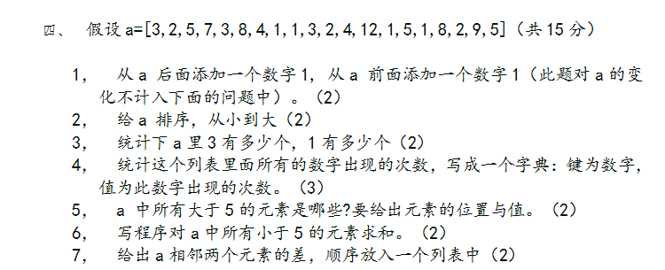

```python
#题目如下，请不要运行此行，否则会失去题目
from IPython.display import Image
Image(filename="2.png")
```

```python
a=[3,2,5,7,3,8,4,1,1,3,2,4,12,1,5,1,8,2,9,5]
```

```python
a
```

```
[1, 1, 1, 1, 1, 1, 2, 2, 2, 3, 3, 3, 4, 4, 5, 5, 5, 7, 8, 8, 9, 12]
```

```python
d={}
for i in a:
    d[i]=d.get(i,0)+1
print(d)
```

```
{1: 6, 2: 3, 3: 3, 4: 2, 5: 3, 7: 1, 8: 2, 9: 1, 12: 1}
```

```python
a.append(1)
```

```python
a
```

```
[3, 2, 5, 7, 3, 8, 4, 1, 1, 3, 2, 4, 12, 1, 5, 1, 8, 2, 9, 5, 1]
```

```python
a.insert(0,1)
a
```

```
[1, 3, 2, 5, 7, 3, 8, 4, 1, 1, 3, 2, 4, 12, 1, 5, 1, 8, 2, 9, 5, 1]
```

```python
a.sort()
a
```

```
[1, 1, 1, 1, 1, 1, 2, 2, 2, 3, 3, 3, 4, 4, 5, 5, 5, 7, 8, 8, 9, 12]
```

```python
a.count(3)
```

```
3
```

```python
a.count(1)
```

```
6
```

```python
d1={}
for i in a:
    d1[i]=d1.get(i,0)+1
print(d1)
```

```
{1: 6, 2: 3, 3: 3, 4: 2, 5: 3, 7: 1, 8: 2, 9: 1, 12: 1}
```

```python
#大于5的位置
for i,j in enumerate(a):
    if j>5:
        print(i,j)
```

```
17 7
18 8
19 8
20 9
21 12
```

```python
s1=0
for i in a:
    if i<5:
        s1=s1+i
print(s1)
```

```
29
```

```python
x1=[]
for i in range(0,len(a)-1):
    x1.append(a[i]-a[i+1])
print(x1)
```

```
[0, 0, 0, 0, 0, -1, 0, 0, -1, 0, 0, -1, 0, -1, 0, 0, -2, -1, 0, -1, -3]
```